# 03. Aesthetics and Scales

## Scales

Each aesthetic within the grammar of graphics is associated with a scale. Scales detail how a plot should relate aesthetics to the concrete, perceivable features in a plot. For example, a scale for the `x` aesthetic will describe the smallest and largest values on the x-axis. It will additionally set things such as the tick marks on the axis.

In order to change or modify the default scales, we add an additional item to the ggplot code. The order of the scales relative to the geoms does not effect the output; by convention, scales are usually grouped after the geometries. These functions always start with **scale_** followed by the name of the aesthetic.

As an example, consider a scatter plot with calories on the x-axis and sugar content on the y-axis. Here’s what the default plot looks like if we let R pick the scale of the axes:

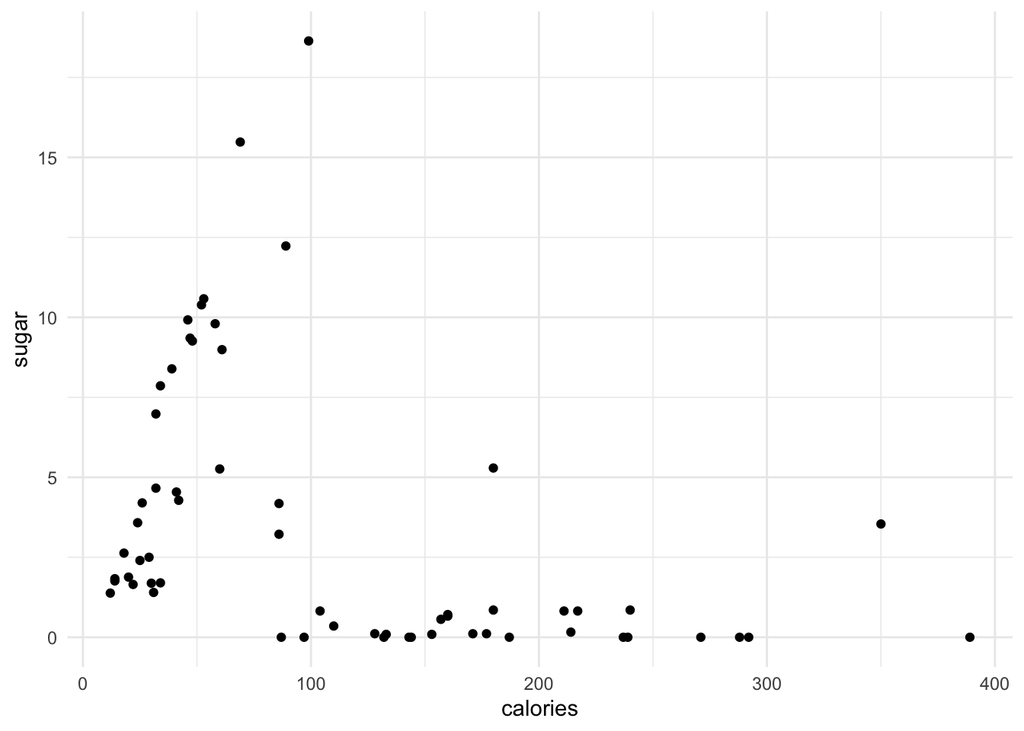

```r
food |>
  ggplot() +
    geom_point(aes(x = calories, y = sugar))
```

We can modify the scale by manually specifying the scale of, say, the x-axis. Here are some options (the first is the default):

- `scale_x_continuous()`
- `scale_x_reverse()`
- `scale_x_log10()`
- `scale_x_sqrt()`

There are `_y_` equivalents of all of these as well. Here is an example where we reverse the x-axis direction:

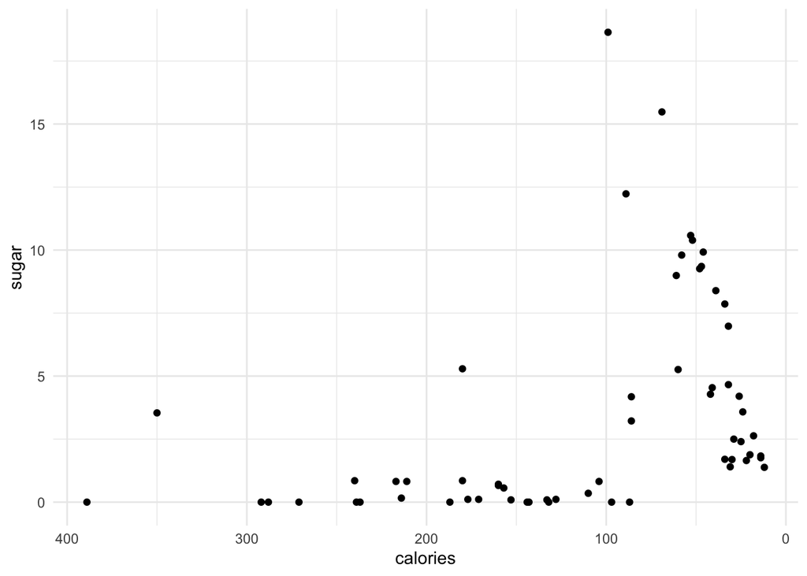

```r
food |>
  ggplot() +
    geom_point(aes(x = calories, y = sugar)) +
    scale_x_reverse()
```

Another way to adjust the scale is to pass optional arguments to the scale function. Two common options are `limits`, which takes two numbers and sets the bounds of the axis:

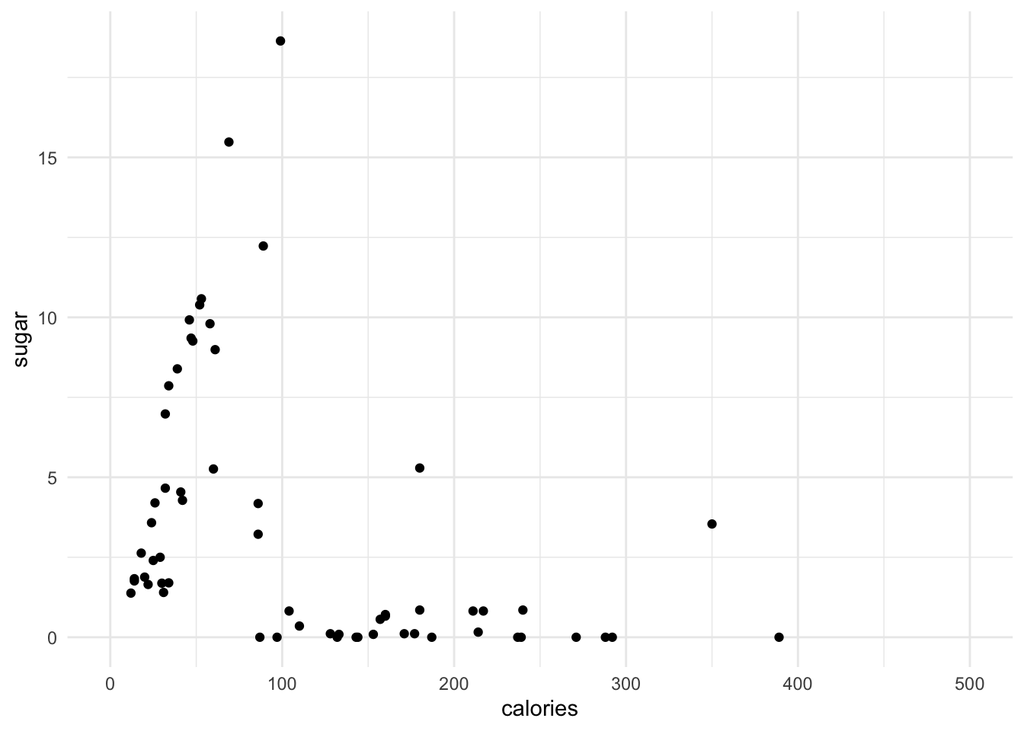

```r
food |>
  ggplot() +
    geom_point(aes(x = calories, y = sugar)) +
    scale_x_continuous(limits = c(0, 500))
```

And `n.breaks`, which sets the number of labels on the axis:

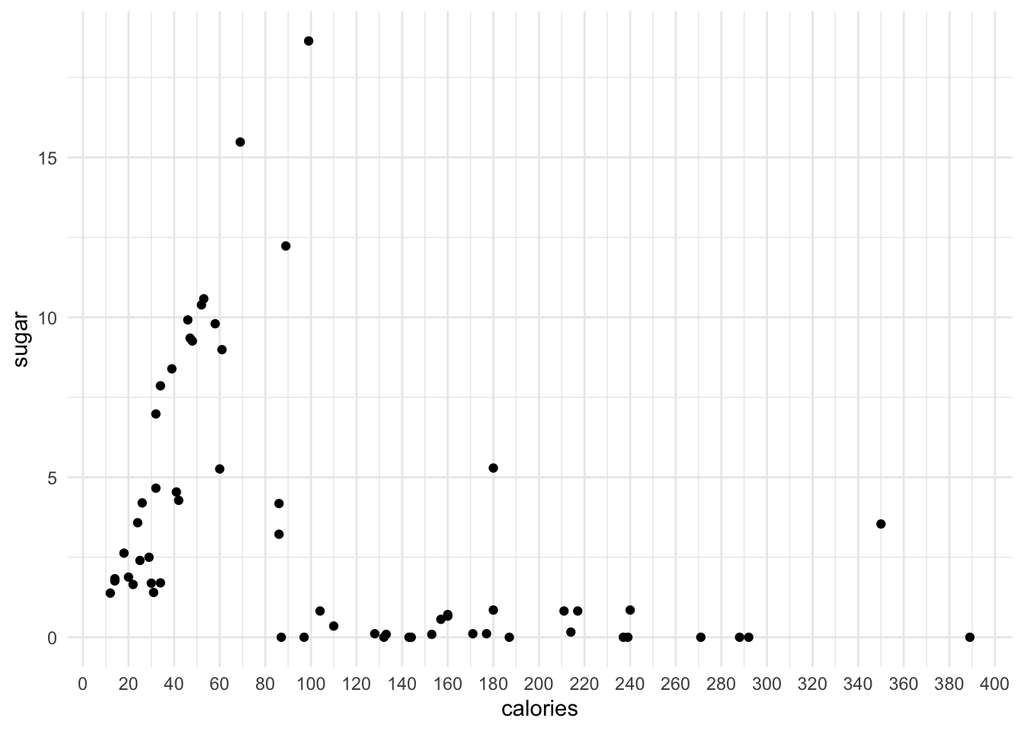

```r
food |>
  ggplot() +
    geom_point(aes(x = calories, y = sugar)) +
    scale_x_continuous(n.breaks = 20)
```

There are many other options that can be specified within the x and y scales, all of which are documented in the help pages, but these are the two I find to be the most frequently needed.

## More Aesthetics: Color and Size

In addition to the required aesthetics, each geometry type also has a number of optional aesthetics that we can use to add additional information to the plot. For example, most geoms have a `color` aesthetic. The syntax for describing this is exactly the same as with the required aesthetics; we place the name of the aesthetic followed by the name of the associated feature name. Let’s see what happens when add a color aesthetic this to our scatterplot by relating the feature `food_group` to the aes `color`:

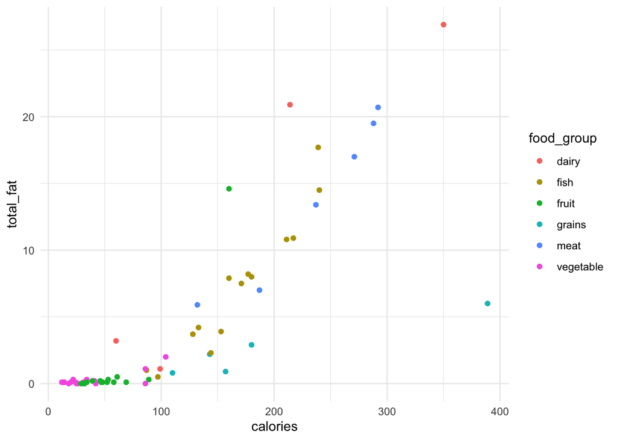

```r
food |>
  ggplot() +
    geom_point(aes(x = calories, y = total_fat, color = food_group))
```

Notice that R has done a lot of work for us. It determined all of the food groups in the data set, assigned each to a color, built a legend, and modified the points on the plot so that the colors align with the food groups. Can you now tell what types of food have a large number of calories and fat? Which kinds of food have the lowest calories and fat? What is the biggest difference between fruits and vegetables from the plot?

Similarly, we can modify the size of the points according to a feature in the data set by setting the `size` aesthetic. Here, we will make points larger or smaller based on the saturated fat in each food item:

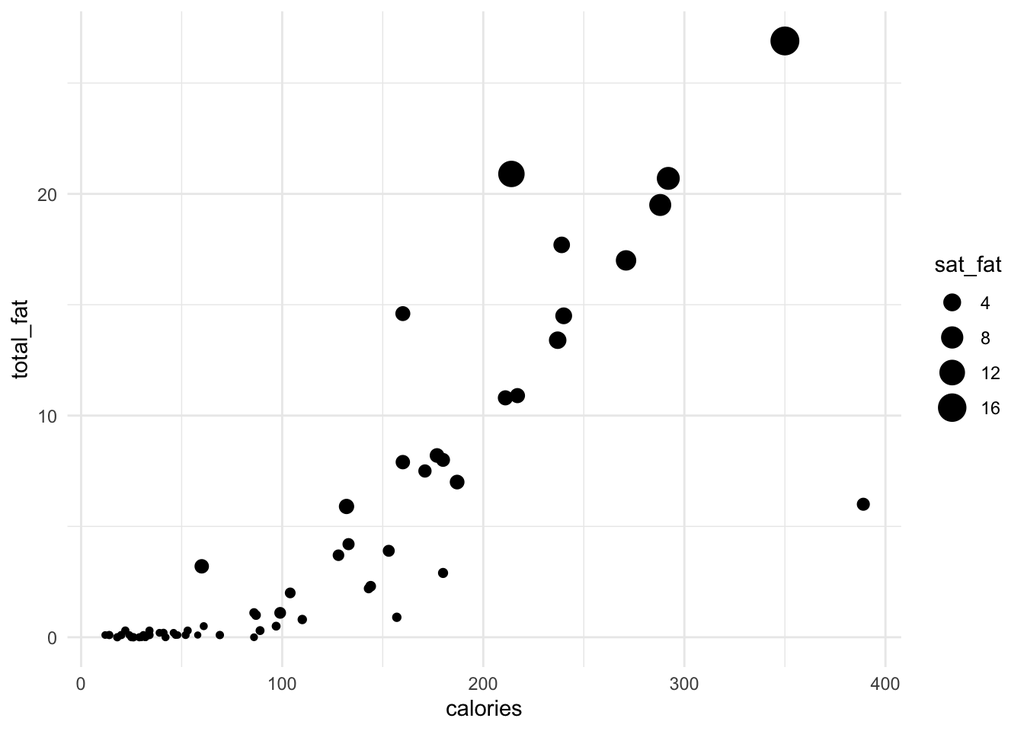

```r
food |>
  ggplot() +
    geom_point(aes(x = calories, y = total_fat, size = sat_fat))
```

Both size and color can also be specified for the text, text repel, and line geometries. There are a few other aesthetics that will be useful, and that we will introduce as needed.

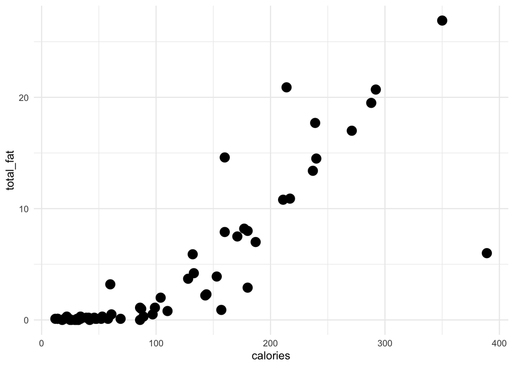

```r
food |>
  ggplot() +
    geom_point(aes(x = calories, y = total_fat), size = 4)
```

We can do the same with colors, but notice that we need to put the color name inside of quotes:

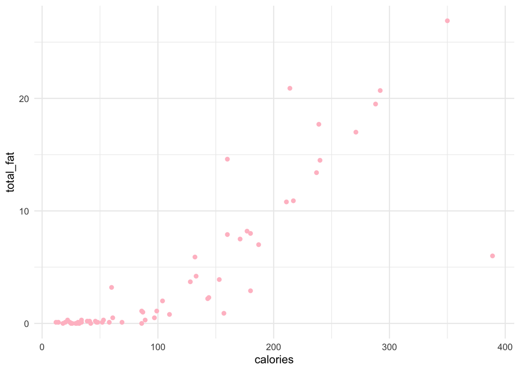

```r
food |>
  ggplot() +
    geom_point(aes(x = calories, y = total_fat), color = "pink")
```

You can interchange the fixed and feature-based aes commands, and the relative order should not effect the output. Just be sure the put fixed terms after closing the aes command.

## Scales for Color and Size

Just as with the x- and y-axes, color and size have scales attached to them as well. It is actually quite common to what to adjust thesse.

For example, a popular alternative to the default color palette shown above is the function `scale_color_viridis_d()`. It constructs a set of colors that is: (1) color-blind friendly, (2) looks nice when printed in black and white, and (3) still displays fine on bad projectors. To use it, add the function `scale_color_viridis_d` on as an extra row to the plot:

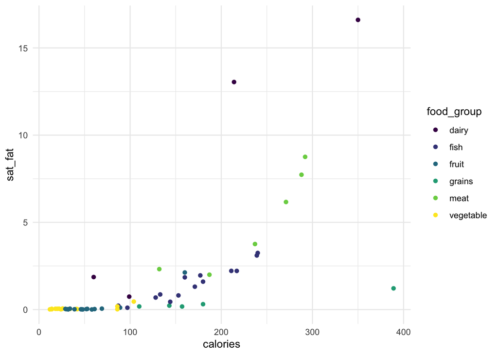

```r
food |>
  ggplot() +
    geom_point(aes(x = calories, y = sat_fat, color = food_group)) +
    scale_color_viridis_d()
```

There is also `scale_color_viridis_c` that produces a similar set of colors when you want to color points according to a numeric feature.

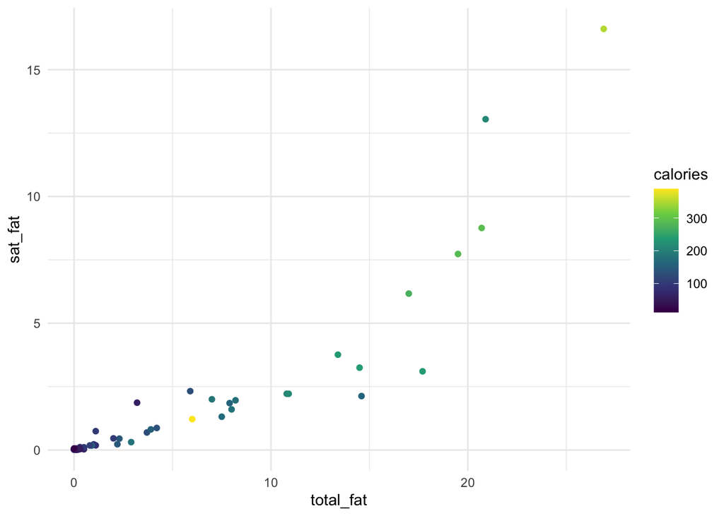

```r
food |>
  ggplot() +
    geom_point(aes(x = total_fat, y = sat_fat, color = calories)) +
    scale_color_viridis_c()
```

There are several special scale types that can be useful for working with colors. In some cases we may already have a column in our data set that explicitly describes the color of an observations. This is, in fact, the case with the food data set. In this case, we may want to use these colors directly. To do that, use the scale `scale_color_identity`. Here is an example with each food colored according to its assigned color:

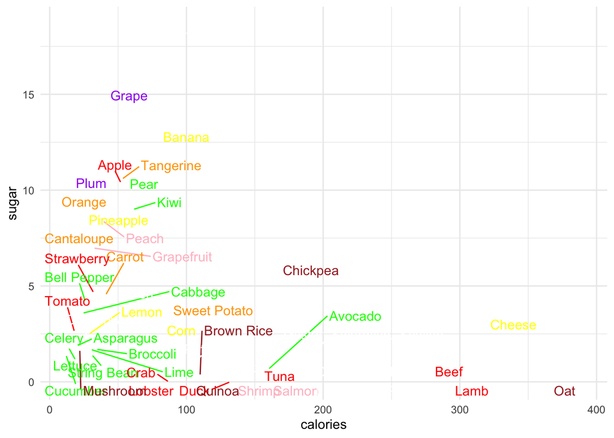

```r
food |>
  ggplot() +
    geom_text_repel(
      aes(x = calories, y = sugar, color = color, label = item)
    ) +
    scale_color_identity()
```

Notice that by default no legend is created for the scale.

Another type of scale that can be useful for colors is `scale_color_manual`. Here, it is possible to describe exactly which color should be used for each category. Here is the syntax, with manually defined colors for each food group:

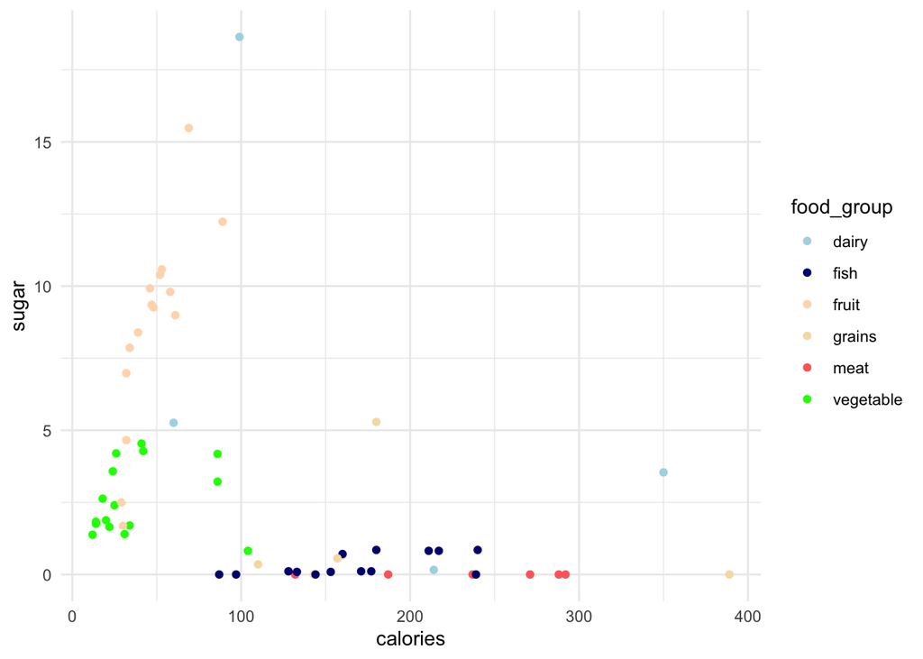

```r
food |>
  ggplot() +
    geom_point(aes(x = calories, y = sugar, color = food_group)) +
    scale_color_manual(values = c(
      dairy = "lightblue",
      fish = "navy",
      fruit = "peachpuff1",
      grains = "wheat",
      meat = "indianred1",
      vegetable = "green"
    ))
```

Using manual colors is generally advisable in the case where there are well-known colors associated with the groups in the data set. For example, when plotting data about political parties it may make be helpful to use the colors traditionally associated with each party.

## Inheritance of aesthetics

As a final optional point, note that there is a convention for simplifying the plotting command. Often, each layer will use the same x and y features. It is possible to specify these just once in the `ggplot` function, and they will be used by default in all other layers. Also, you can drop the `x =` and `y =` if you put these options first. Here is an example of layering together the `geom_point` and `geom_text_repel` with this inheritance structure:

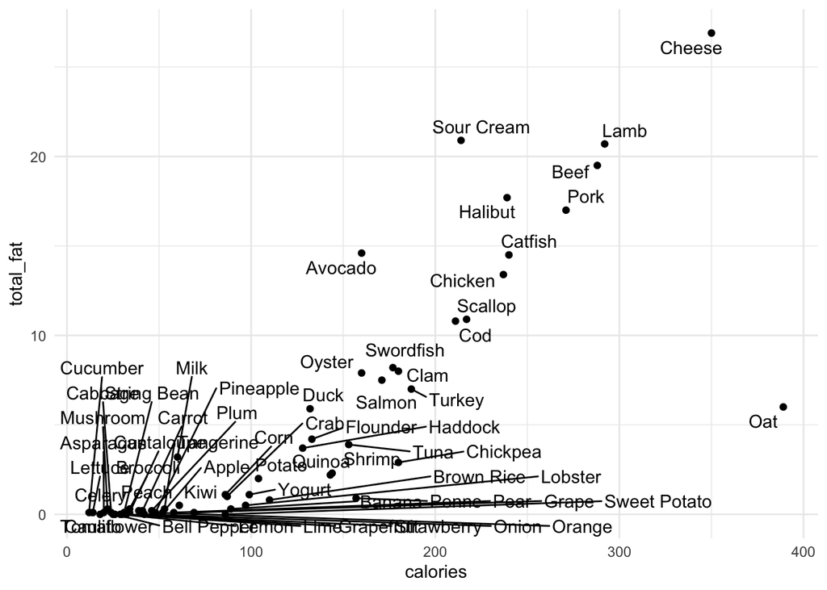

```r
food |>
  ggplot(aes(calories, total_fat)) +
    geom_point() +
    geom_text_repel(aes(label = item))
```

These changes are optional however, and you can feel free to write them as we did earlier if you prefer. It is important to be able to recognize them, though, if you are searching through documentation or help pages.

## Homework Questions

For this class assignment, find a data visualization somewhere online that is similar to the plots in these notes (in other words, do not pick something too complicated). Some examples of places to look include [The Pudding](https://pudding.cool/) and the [Reddit Data is Beautful channel](https://www.reddit.com/r/dataisbeautiful/). You could even search through the archives of some of the popular techie webcomics, such [xkcd](https://www.google.com/search?q=phd+comics+plots&tbm=isch), [smbc](https://www.google.com/search?q=smbc+plots&tbm=isch), or [Ph.D. Comics](https://www.google.com/search?q=phd+comics+plots&tbm=isch)

Once you have found a data visualization, write down as best as possible how you would need to structure a dataset to create the visualization and briefly explain you would use different aesthetics and geometries to create it. Make sure you have a link to the visualization that you can share in class.